# HW4

11

September 27, 2016

# Part 1: Linear Regression Concepts

These questions do not require coding but will explore some important concepts from lecture 5.

“Regression” refers to the simple linear regression equation:
$$y = B_0 + B_1 x$$

1. (1 pt) What is the interpretation of the coefficient B1? (What meaning does it represent?)

The amount the dependent (y) variable is expected to change as a result of a unit increase of the independent variable(x)

2. (1 pt) If the residual sum of squares (RSS) of my regression is exactly 0, what does that mean about my model?

The model is a perfect fit. There is no discrepancy between the estimated and true values of the data.

3. (2 pt) Outliers are problems for many statistical methods, but are particularly problematic for linear regression. Why is that? It may help to define what outlier means in this case. (Hint: Think of how residuals are calculated)

Outliers put a disproportionate weight on the model and pull the expected values closer to themselves. This can result in either amplified or diminished trends.

# Part 2: Sampling and Point Estimation

The following problems will use the ggplot2movies data set and explore the average movie length of films in the year 2000.

Load the data by running the following code

```r
install.packages("ggplot2movies", repos="http://ftp.ussg.iu.edu/CRAN/")
```

```r
library(ggplot2movies)
data(movies)
print(names(movies))
```

```
##  [1] "title"       "year"        "length"      "budget"      "rating"
##  [6] "votes"       "r1"          "r2"          "r3"          "r4"
## [11] "r5"          "r6"          "r7"          "r8"          "r9"
## [16] "r10"         "mpaa"        "Action"      "Animation"   "Comedy"
## [21] "Drama"       "Documentary" "Romance"     "Short"
```

4. (2 pts) Subset the data frame to ONLY include movies released in 2000.

```r
temp = movies[movies$year == 2000, ]
```

Use the sample function to generate a vector of 1s and 2s that is the same length as the subsetted data frame. Use this vector to split the ‘length’ variable into two vectors, length1 and length2.

IMPORTANT: Make sure to run the following seed function before you run your sample function. Run them back to back each time you want to run the sample function.

Check: If you did this properly, you will have 1035 elements in length1 and 1013 elements in length2.

```r
set.seed(1848)
sample = sample(2, length(temp$title), replace=TRUE, prob=NULL)

length1 = temp$length[sample == 1]
length2 = temp$length[sample == 2]

print(length(length1))
```

```
## [1] 1035
```

```r
print(length(length2))
```

```
## [1] 1013
```

5. (3 pts) Calculate the mean and the standard deviation for each of the two vectors, length1 and length2. Use this information to create a 95% confidence interval for your sample means. Compare the confidence intervals – do they seem to agree or disagree?

```r
mean1 = mean(length1)
mean2 = mean(length2)

sd1 = sd(length1)
sd2 = sd(length2)

error1 = qnorm(0.95) * sd1/sqrt(length(length1))
error2 = qnorm(0.95) * sd2/sqrt(length(length2))

CI1 = c(mean1 - error1, mean1 + error1)
CI2 = c(mean2 - error2, mean2 + error2)

print(CI1)
```

```
## [1] 76.28739 80.38508
```

```r
print(CI2)
```

```
## [1] 77.98859 82.05287
```

6. (4 pts) Draw 100 observations from a standard normal distribution. Calculate the sample mean. Repeat this 100 times, storing each sample mean in a vector called mean_dist.

Plot a histogram of mean_dist to display the sampling distribution.

How closely does your histogram resemble the standard normal? Explain why it does or does not.

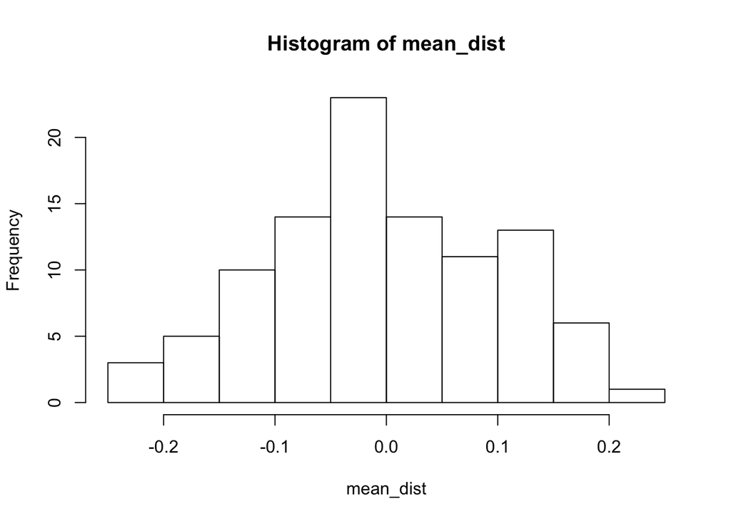

```r
mean_dist = numeric()

set.seed(1848)
for(i in 1:100)
    mean_dist = c(mean_dist, mean(rnorm(100)))

hist(mean_dist)
```

The histogram doesn’t appear to resemble a standard normal distribution. It’s mean seems to be below it’s median, which would suggest a leftward skew in the distribution.

7. (3 pts) Write a function that implements Q6.

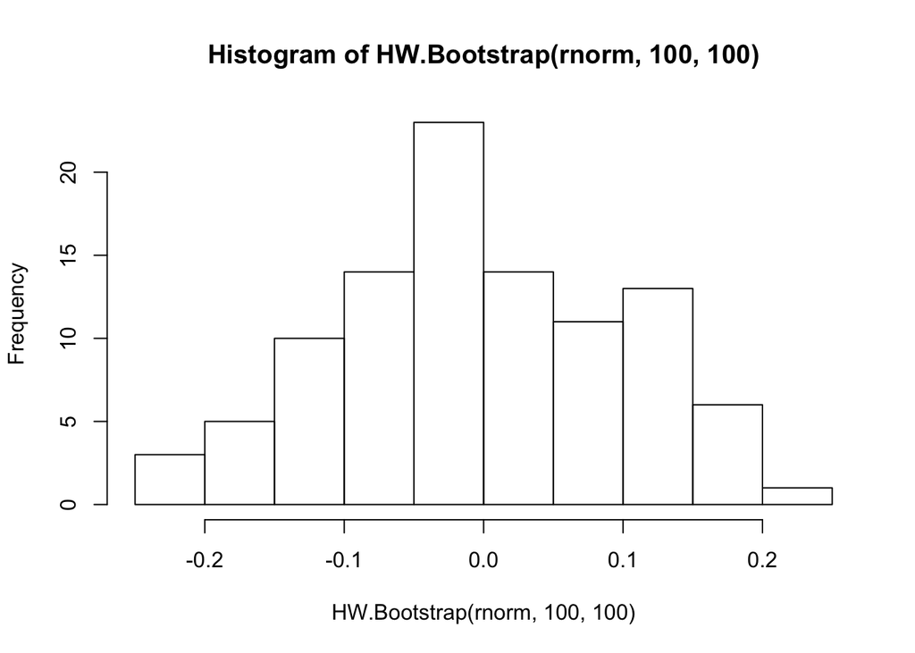

```r
HW.Bootstrap=function(distn,n,reps){
  set.seed(1848)
  temp = numeric()

  for(i in 1: reps){
    temp = c(temp, mean(distn(n)))
  }
  return(temp)
}

hist(HW.Bootstrap(rnorm, 100, 100))
```

# Part 3: Linear Regression

This problem will use the Boston Housing data set. Before starting this problem, we will declare a null hypthosesis that the crime rate has no effect on the housing value for Boston suburbs.That is:
$$H_0: B_1 = 0$$
$$H_A: B_1 \neq 0$$

We will attempt to reject this hypothesis by using a linear regression

```r
housing <- read.table(url("https://archive.ics.uci.edu/ml/machine-learning-databases/housing/housing.data"),sep="")
names(housing) <- c("CRIM","ZN","INDUS","CHAS","NOX","RM","AGE","DIS","RAD","TAX","PTRATIO","B","LSTAT","MEDV")
```

7. (2 pt) Fit a linear regression using the housing data using CRIM (crime rate) to predict MEDV (median home value). Examine the model diagnostics using plot(). Would you consider this a good model or not? Explain.

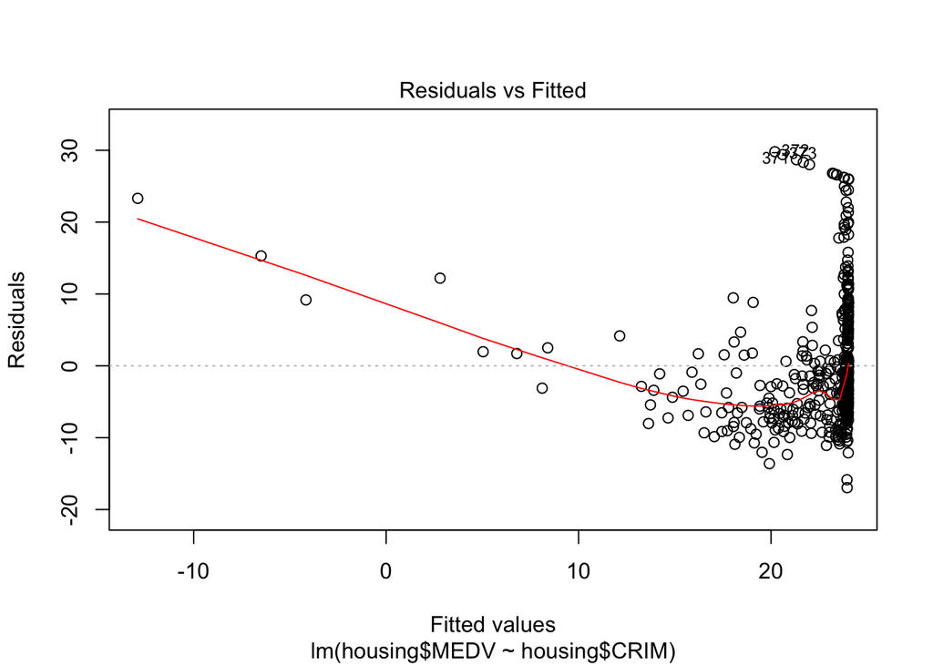

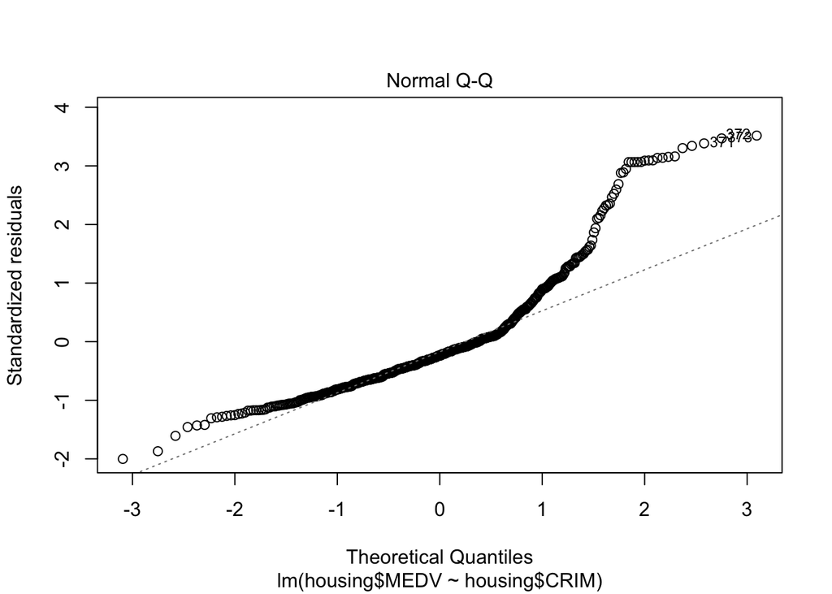

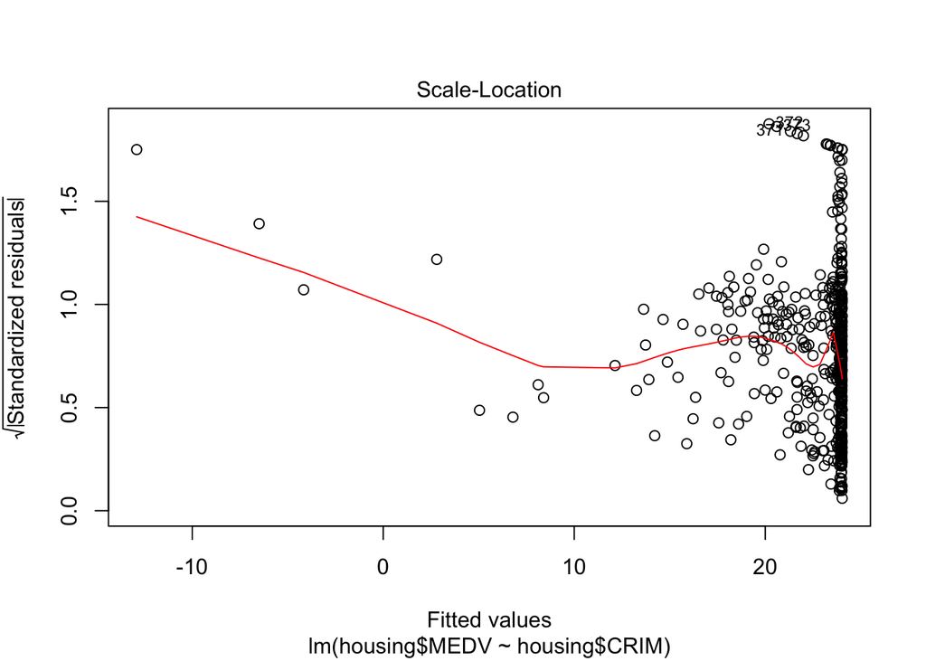

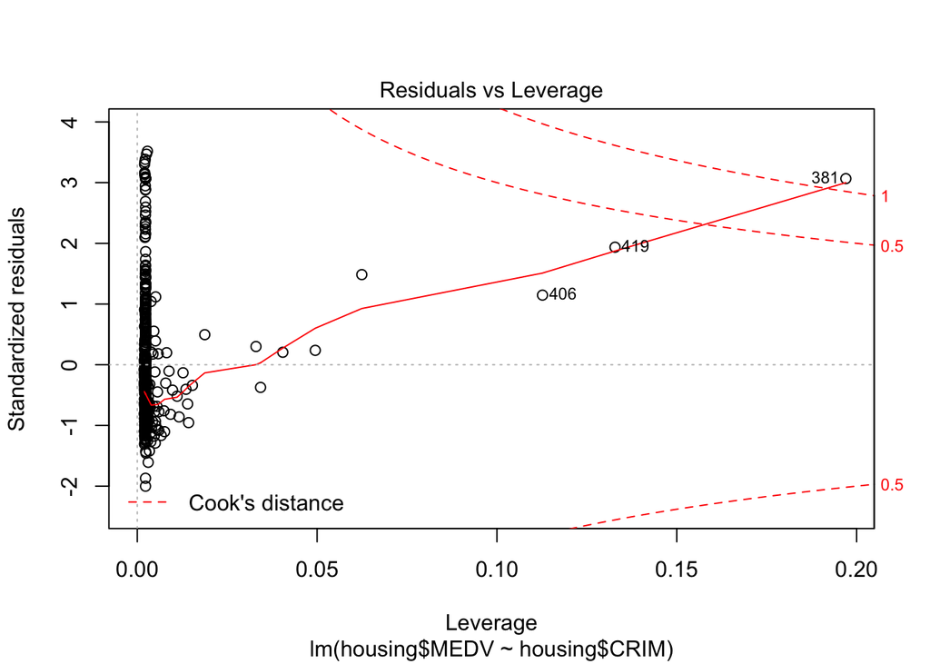

```r
model = lm(housing$MEDV~housing$CRIM)
plot(model)
```

```r
print(summary(model))
```

```
##
## Call:
## lm(formula = housing$MEDV ~ housing$CRIM)
##
## Residuals:
##     Min      1Q  Median      3Q     Max
## -16.957  -5.449  -2.007   2.512  29.800
##
## Coefficients:
##              Estimate Std. Error t value Pr(>|t|)
## (Intercept)  24.03311    0.40914   58.74   <2e-16 ***
## housing$CRIM -0.41519    0.04389   -9.46   <2e-16 ***
## ---
## Signif. codes:  0 '***' 0.001 '**' 0.01 '*' 0.05 '.' 0.1 ' ' 1
##
## Residual standard error: 8.484 on 504 degrees of freedom
## Multiple R-squared:  0.1508, Adjusted R-squared:  0.1491
## F-statistic: 89.49 on 1 and 504 DF,  p-value: < 2.2e-16
```

```r
print(confint(model, level=0.95))
```

```
##                   2.5 %     97.5 %
## (Intercept)  23.2292723 24.8369400
## housing$CRIM -0.5014209 -0.3289596
```

9. (2 pts) Based on the result from question 8, would you reject the null hypothesis or not? (Assume a significance level of 0.05). Explain.

Yes, I would reject the null hypothesis because 0 does not fall within the confidence interval.

Additionally, the p-value on the F-test is < 0.05 which means the variables explain a significant part of the variation (so there appears to be a trend)

10. (1 pt) Pretend that the null hypothesis is true. Based on your decision in the previous question, would you be committing a decision error? If so, which one?

Yes, this would be Type I error because we rejected the null hypothesis even though it was true.

11. (1 pt) Use the variable definitions from this site: https://archive.ics.uci.edu/ml/machine-learning-databases/housing/housing.names

Discuss what your regression results mean in the context of the data (using appropriate units)(Hint: Think back to Question 1)

A unit increase in crime rate is expected to decrease the median value of owner occupied homes by $415.19

12. (2 pt) Describe the LifeCycle of Data for Part 3 of this homework.

Data is acquired from a source (either measured, observed, or generated), then cleaned and edited to prepare it for analysis.It is used in analysis to lead to insight, action, or decision, then published and dissemminated and ultimately preserved for replication or reuse.